# Tugas3

Amal

2023-09-17

## *Packages*

```r
library(dLagM)
library(dynlm)
library(MLmetrics)
library(lmtest)
library(car)
```

## Impor Data

```r
meteor1 <- rio::import("https://raw.githubusercontent.com/Safwa40/MPDW/main/Pertemuan%203/Bisayuk.csv")
str(meteor1)
```

```
## 'data.frame':    120 obs. of  4 variables:
##  $     : logi  NA NA NA NA NA NA ...
##  $ TS  : num  14.06 8.08 5.85 0.42 -7.05 ...
##  $ T2M : num  14.24 8.1 5.91 0.35 -6.49 ...
##  $ TS_1: num  NA 14.06 8.08 5.85 0.42 ...
```

```r
meteor1
```

```
##           TS   T2M  TS_1
## 1   NA 14.06 14.24    NA
## 2   NA  8.08  8.10 14.06
## 3   NA  5.85  5.91  8.08
## 4   NA  0.42  0.35  5.85
## 5   NA -7.05 -6.49  0.42
## 6   NA -8.36 -6.38 -7.05
## 7   NA -3.05 -2.14 -8.36
## 8   NA  5.81  5.92 -3.05
## 9   NA 14.21 14.38  5.81
## 10  NA 15.54 15.69 14.21
## 11  NA 15.80 16.70 15.54
## 12  NA 14.44 16.90 15.80
## 13  NA 14.23 15.88 14.44
## 14  NA 15.71 15.81 14.23
```

[output cut: 106 more lines]

## Pembagian Data

```r
#SPLIT DATA
trainmeteor<-meteor1[1:90,]
testmeteor<-meteor1[91:120,]
trainmeteor
```

```
##          TS   T2M  TS_1
## 1  NA 14.06 14.24    NA
## 2  NA  8.08  8.10 14.06
## 3  NA  5.85  5.91  8.08
## 4  NA  0.42  0.35  5.85
## 5  NA -7.05 -6.49  0.42
## 6  NA -8.36 -6.38 -7.05
## 7  NA -3.05 -2.14 -8.36
## 8  NA  5.81  5.92 -3.05
## 9  NA 14.21 14.38  5.81
## 10 NA 15.54 15.69 14.21
## 11 NA 15.80 16.70 15.54
## 12 NA 14.44 16.90 15.80
## 13 NA 14.23 15.88 14.44
## 14 NA 15.71 15.81 14.23
```

[output cut: 76 more lines]

```r
#data time series
trainmeteor.ts<-ts(trainmeteor)
testmeteor.ts<-ts(testmeteor)
meteor.ts<-ts(meteor1)
```

```r
#MODEL KOYCK
modelkoyck <- dLagM::koyckDlm(x = trainmeteor$T2M, y = trainmeteor$TS, TRUE)
summary(modelkoyck)
```

```
##
## Call:
## "Y ~ (Intercept) + Y.1 + X.t"
##
## Residuals:
##     Min      1Q  Median      3Q     Max
## -2.6701 -0.6438  0.2608  0.5869  1.9665
##
## Coefficients:
##             Estimate Std. Error t value Pr(>|t|)
## (Intercept)   0.3850     0.4589   0.839   0.4039
## Y.1           0.2091     0.1029   2.033   0.0451 *
## X.t           0.7477     0.1306   5.724 1.49e-07 ***
## ---
## Signif. codes:  0 '***' 0.001 '**' 0.01 '*' 0.05 '.' 0.1 ' ' 1
##
## Residual standard error: 1.013 on 86 degrees of freedom
## Multiple R-Squared: 0.9721,  Adjusted R-squared: 0.9715
## Wald test: 964.8 on 2 and 86 DF,  p-value: < 2.2e-16
##
## Diagnostic tests:
## NULL
##
##                              alpha      beta       phi
## Geometric coefficients:  0.4868046 0.7477238 0.2091231
```

```r
AIC(modelkoyck)
```

```
## [1] 259.7384
```

```r
BIC(modelkoyck)
```

```
## [1] 269.6929
```

Dari hasil tersebut, didapat bahwa peubah $x_t$ dan $y_{t-1}$ memiliki nilai $P-Value<0.05$. Hal ini menunjukkan bahwa peubah $x_t$ dan $y_{t-1}$ berpengaruh signifikan terhadap $y$. Adapun model keseluruhannya adalah sebagai berikut

$$\hat{Y_t}=0.3850+0.7477X_t+0.2091Y_{t-1}$$

### Peramalan dan Akurasi

Berikut adalah hasil peramalan y untuk 30 periode kedepan menggunakan model koyck

```r
forekoyck <- forecast(model = modelkoyck, x=testmeteor$T2M, h=30)
forekoyck
```

```
## $forecasts
##  [1] 19.39848 19.34381 20.46892 13.97469 12.02589 12.65021 14.30613 16.07309
##  [9] 18.45399 19.84915 20.33532 20.17529 19.85769 19.26039 20.16733 20.73086
## [17] 20.53466 21.61522 21.57201 20.50120 16.14236 14.76724 17.08922 19.08521
## [25] 20.69897 22.26271 22.68693 23.20933 19.39302 20.35957
##
## $call
## forecast.koyckDlm(model = modelkoyck, x = testmeteor$T2M, h = 30)
##
## attr(,"class")
## [1] "forecast.koyckDlm" "dLagM"
```

```r
mapekoyck <- MAPE(forekoyck$forecasts, testmeteor$TS)
mapekoyck
```

```
## [1] 0.03681183
```

```r
is.na(testmeteor$TS)
```

```
##  [1] FALSE FALSE FALSE FALSE FALSE FALSE FALSE FALSE FALSE FALSE FALSE FALSE
## [13] FALSE FALSE FALSE FALSE FALSE FALSE FALSE FALSE FALSE FALSE FALSE FALSE
## [25] FALSE FALSE FALSE FALSE FALSE FALSE
```

```r
#akurasi data training
GoF(modelkoyck)
```

```
##             n       MAE         MPE      MAPE      sMAPE      MASE       MSE
## modelkoyck 89 0.7899611 -0.04650913 0.1200825 0.09385284 0.2703032 0.9906876
##                MRAE     GMRAE
## modelkoyck 0.483372 0.2927441
```

## Regression with Distributed Lag

### Pemodelan (Lag=2)

```r
modeldlm <- dlm(x = trainmeteor$T2M,y = trainmeteor$TS , q = 2)
summary(modeldlm)
```

```
##
## Call:
## lm(formula = model.formula, data = design)
##
## Residuals:
##      Min       1Q   Median       3Q      Max
## -2.30280  0.04091  0.11987  0.21777  0.47308
##
## Coefficients:
##              Estimate Std. Error t value Pr(>|t|)
## (Intercept) -0.350319   0.125439  -2.793  0.00647 **
## x.t          0.997494   0.014026  71.116  < 2e-16 ***
## x.1          0.007320   0.019823   0.369  0.71285
## x.2          0.007216   0.013901   0.519  0.60504
## ---
## Signif. codes:  0 '***' 0.001 '**' 0.01 '*' 0.05 '.' 0.1 ' ' 1
##
## Residual standard error: 0.445 on 84 degrees of freedom
## Multiple R-squared:  0.9947, Adjusted R-squared:  0.9945
## F-statistic:  5267 on 3 and 84 DF,  p-value: < 2.2e-16
##
## AIC and BIC values for the model:
##        AIC      BIC
## 1 113.1536 125.5403
```

```r
AIC(modeldlm)
```

```
## [1] 113.1536
```

```r
BIC(modeldlm)
```

```
## [1] 125.5403
```

Dari hasil diatas, didapat bahwa $P-value$ dari intercept dan $x_{t}<0.05$. Hal ini menunjukkan bahwa intercept dan $x_{t1}$ berpengaruh signifikan terhadap $y$. Adapun model keseluruhan yang terbentuk adalah sebagai berikut

$$\hat{Y_t}=-0.350319+0.997494X_t+0.007320X_{t-1}+0.007216X_{t-2}$$

### Peramalan dan Akurasi

Berikut merupakan hasil peramalan $y$ untuk 30 periode kedepan

```r
foredlm <- forecast(model = modeldlm, x=testmeteor$T2M, h=30)
foredlm
```

```
## $forecasts
##  [1] 20.11765 19.81125 21.33802 12.36932 11.52638 12.83220 14.87148 16.79161
##  [9] 19.50350 20.73390 21.02144 20.68288 20.30315 19.58962 20.95822 21.46195
## [17] 21.05662 22.55339 22.20224 20.79399 15.26486 14.59568 18.03249 20.06850
## [25] 21.70447 23.36664 23.51987 24.11120 18.87954 21.19938
##
## $call
## forecast.dlm(model = modeldlm, x = testmeteor$T2M, h = 30)
##
## attr(,"class")
## [1] "forecast.dlm" "dLagM"
```

```r
mapedlm <- MAPE(foredlm$forecasts, testmeteor$TS)
#akurasi data training
GoF(modeldlm)
```

```
##           n      MAE        MPE       MAPE      sMAPE       MASE       MSE
## modeldlm 88 0.268146 0.02050688 0.03887756 0.04485036 0.09150304 0.1890627
##               MRAE      GMRAE
## modeldlm 0.3316569 0.09542495
```

### *Lag* Optimum

```r
#penentuan lag optimum
finiteDLMauto(formula = TS ~ T2M,
              data = data.frame(trainmeteor), q.min = 1, q.max = 10,
              model.type = "dlm", error.type = "AIC", trace = FALSE)
```

```
##   q - k    MASE      AIC      BIC   GMRAE   MBRAE R.Adj.Sq   Ljung-Box
## 7     7 0.08019 80.82372 105.0121 0.06636 0.04923  0.99402 8.84032e-05
```

Berdasarkan output tersebut, lag optimum didapatkan ketika lag=7. Selanjutnya dilakukan pemodelan untuk lag=7

```r
#model dlm dengan lag optimum
modeldlm2 <- dlm(x = trainmeteor$T2M,y = trainmeteor$TS , q = 7)
summary(modeldlm2)
```

```
##
## Call:
## lm(formula = model.formula, data = design)
##
## Residuals:
##      Min       1Q   Median       3Q      Max
## -1.69676 -0.03533  0.05314  0.19055  0.51705
##
## Coefficients:
##               Estimate Std. Error t value Pr(>|t|)
## (Intercept) -0.2921043  0.1608685  -1.816   0.0735 .
## x.t          0.9849108  0.0132790  74.171   <2e-16 ***
## x.1          0.0002307  0.0186375   0.012   0.9902
## x.2         -0.0056589  0.0198852  -0.285   0.7768
## x.3          0.0063204  0.0197244   0.320   0.7495
## x.4         -0.0106748  0.0197578  -0.540   0.5906
## x.5          0.0176910  0.0196776   0.899   0.3715
## x.6          0.0224089  0.0183839   1.219   0.2267
## x.7         -0.0033804  0.0122298  -0.276   0.7830
## ---
## Signif. codes:  0 '***' 0.001 '**' 0.01 '*' 0.05 '.' 0.1 ' ' 1
##
## Residual standard error: 0.3697 on 74 degrees of freedom
## Multiple R-squared:  0.9946, Adjusted R-squared:  0.994
## F-statistic:  1706 on 8 and 74 DF,  p-value: < 2.2e-16
##
## AIC and BIC values for the model:
##        AIC      BIC
## 1 80.82372 105.0121
```

```r
AIC(modeldlm2)
```

```
## [1] 80.82372
```

```r
BIC(modeldlm2)
```

```
## [1] 105.0121
```

Adapun hasil peramalan 30 periode kedepan menggunakan model tersebut adalah sebagai berikut

```r
#peramalan dan akurasi
foredlm2 <- forecast(model = modeldlm2, x=testmeteor$T2M, h=30)
mapedlm2<- MAPE(foredlm2$forecasts, testmeteor$TS)
mapedlm2
```

```
## [1] 0.01153237
```

```r
#akurasi data training
GoF(modeldlm2)
```

```
##            n       MAE           MPE       MAPE      sMAPE       MASE       MSE
## modeldlm2 83 0.2215784 -0.0008029628 0.02060675 0.02023326 0.08019345 0.1218382
##                MRAE      GMRAE
## modeldlm2 0.2710675 0.06636471
```

Model tersebut merupakan model yang sangat baik dengan nilai MAPE yang kurang dari 5%.

## Model Autoregressive

Peubah dependen dipengaruhi oleh peubah independen pada waktu sekarang, serta dipengaruhi juga oleh peubah dependen itu sendiri pada satu waktu yang lalu maka model tersebut disebut *autoregressive* (Gujarati 2004).

### Pemodelan

Dengan $p$ adalah integer yang mewakili panjang *lag* yang terbatas dan $q$ adalah integer yang merepresentasikan ordo dari proses *autoregressive*.

```r
modelardl <- ardlDlm(x = trainmeteor$T2M, y = trainmeteor$TS, p = 1 , q = 1)
summary(modelardl)
```

```
##
## Time series regression with "ts" data:
## Start = 2, End = 90
##
## Call:
## dynlm(formula = as.formula(model.text), data = data, start = 1)
##
## Residuals:
##      Min       1Q   Median       3Q      Max
## -1.95570  0.00804  0.06876  0.16698  0.77874
##
## Coefficients:
##             Estimate Std. Error t value Pr(>|t|)
## (Intercept) -0.20625    0.10220  -2.018   0.0467 *
## X.t          1.00195    0.01132  88.506  < 2e-16 ***
## X.1         -0.48272    0.09716  -4.968 3.45e-06 ***
## Y.1          0.48927    0.09475   5.164 1.57e-06 ***
## ---
## Signif. codes:  0 '***' 0.001 '**' 0.01 '*' 0.05 '.' 0.1 ' ' 1
##
## Residual standard error: 0.3868 on 85 degrees of freedom
## Multiple R-squared:  0.996,  Adjusted R-squared:  0.9958
## F-statistic:  7019 on 3 and 85 DF,  p-value: < 2.2e-16
```

```r
AIC(modelardl)
```

```
## [1] 89.40971
```

```r
BIC(modelardl)
```

```
## [1] 101.8529
```

Hasil di atas menunjukkan bahwa semua peubah, hasil uji t menunjukkan nilai-p pada peubah $<0.05$ Hal ini menunjukkan bahwa peubah semuanya berpengaruh signifikan terhadap $y_t$. Model keseluruhannya adalah sebagai berikut:

$$\hat{Y}=-0.20625+1.00195X_t-0.48272X_{t-1}+0.48927Y_{t-1}$$

### Peramalan dan Akurasi

```r
foreardl <- forecast(model = modelardl, x=testmeteor$T2M, h=30)
foreardl
```

```
## $forecasts
##  [1] 20.22390 19.87761 21.39043 12.37935 11.52344 12.86870 14.90472 16.81983
##  [9] 19.53491 20.76714 21.05127 20.71410 20.33735 19.62506 21.00198 21.51049
## [17] 21.09711 22.60051 22.25131 20.83146 15.28147 14.61426 18.08389 20.12072
## [25] 21.74530 23.41100 23.56458 24.15809 18.90828 21.23858
##
## $call
## forecast.ardlDlm(model = modelardl, x = testmeteor$T2M, h = 30)
##
## attr(,"class")
## [1] "forecast.ardlDlm" "dLagM"
```

```r
mapeardl <- MAPE(foreardl$forecasts, testmeteor$TS)
mapeardl
```

```
## [1] 0.01023305
```

```r
#akurasi data training
GoF(modelardl)
```

```
##            n       MAE       MPE       MAPE      sMAPE       MASE       MSE
## modelardl 89 0.2228301 0.0128293 0.03202721 0.03540577 0.07624641 0.1428967
##                MRAE      GMRAE
## modelardl 0.2414603 0.06206503
```

Berdasarkan akurasi di atas, terlihat bahwa nilai MAPE keduanya tidak jauh berbeda. Artinya, model regresi dengan distribusi lag ini tidak `overfitted` atau `underfitted`

### *Lag* Optimum

```r
#penentuan lag optimum
model.ardl.opt <- ardlBoundOrders(data = data.frame(meteor1), ic = "AIC",
                                  formula = TS ~ T2M )
min_p=c()
for(i in 1:6){
  min_p[i]=min(model.ardl.opt$Stat.table[[i]])
}
q_opt=which(min_p==min(min_p, na.rm = TRUE))
p_opt=which(model.ardl.opt$Stat.table[[q_opt]] ==
              min(model.ardl.opt$Stat.table[[q_opt]], na.rm = TRUE))
data.frame("q_optimum" = q_opt, "p_optimum" = p_opt,
           "AIC"=model.ardl.opt$min.Stat)
```

```
##   q_optimum p_optimum      AIC
## 1         2        12 22.69813
```

Selanjutnya dapat dilakukan pemodelan dengan nilai $p$ dan $q$ optimum seperti inisialisasi di langkah sebelumnya.

## Pemodelan DLM & ARDL dengan Library `dynlm`

Untuk menentukan `formula` model yang akan digunakan, tersedia fungsi tambahan yang memungkinkan spesifikasi dinamika (melalui `d()` dan `L()`) atau pola linier/siklus dengan mudah (melalui `trend()`, `season()`, dan `harmon()`). Semua fungsi formula baru mengharuskan argumennya berupa objek deret waktu (yaitu, `"ts"` atau `"zoo"`).

```r
#sama dengan model dlm q=1
cons_lm1 <- dynlm(TS ~ T2M+L(T2M),data = trainmeteor.ts)
#sama dengan model ardl p=1 q=0
cons_lm2 <- dynlm(TS ~ T2M+L(TS),data = trainmeteor.ts)
#sama dengan ardl p=1 q=1
cons_lm3 <- dynlm(TS ~ T2M+L(T2M)+L(TS),data = trainmeteor.ts)
#sama dengan dlm p=2
cons_lm4 <- dynlm(TS ~ T2M+L(T2M)+L(T2M,2),data = trainmeteor.ts)
```

### Ringkasan Model

```r
summary(cons_lm1)
```

```
##
## Time series regression with "ts" data:
## Start = 2, End = 90
##
## Call:
## dynlm(formula = TS ~ T2M + L(T2M), data = trainmeteor.ts)
##
## Residuals:
##     Min      1Q  Median      3Q     Max
## -2.3015  0.0378  0.1209  0.2203  0.4662
##
## Coefficients:
##             Estimate Std. Error t value Pr(>|t|)
## (Intercept) -0.32211    0.11361  -2.835  0.00571 **
## T2M          0.99425    0.01279  77.752  < 2e-16 ***
## L(T2M)       0.01561    0.01286   1.214  0.22793
## ---
## Signif. codes:  0 '***' 0.001 '**' 0.01 '*' 0.05 '.' 0.1 ' ' 1
##
## Residual standard error: 0.4408 on 86 degrees of freedom
## Multiple R-squared:  0.9947, Adjusted R-squared:  0.9946
## F-statistic:  8098 on 2 and 86 DF,  p-value: < 2.2e-16
```

```r
summary(cons_lm2)
```

```
##
## Time series regression with "ts" data:
## Start = 2, End = 90
##
## Call:
## dynlm(formula = TS ~ T2M + L(TS), data = trainmeteor.ts)
##
## Residuals:
##      Min       1Q   Median       3Q      Max
## -2.29158  0.02079  0.11545  0.21948  0.46662
##
## Coefficients:
##             Estimate Std. Error t value Pr(>|t|)
## (Intercept) -0.33424    0.11169  -2.993  0.00361 **
## T2M          0.98950    0.01247  79.364  < 2e-16 ***
## L(TS)        0.02172    0.01243   1.748  0.08403 .
## ---
## Signif. codes:  0 '***' 0.001 '**' 0.01 '*' 0.05 '.' 0.1 ' ' 1
##
## Residual standard error: 0.4368 on 86 degrees of freedom
## Multiple R-squared:  0.9948, Adjusted R-squared:  0.9947
## F-statistic:  8245 on 2 and 86 DF,  p-value: < 2.2e-16
```

```r
summary(cons_lm3)
```

```
##
## Time series regression with "ts" data:
## Start = 2, End = 90
##
## Call:
## dynlm(formula = TS ~ T2M + L(T2M) + L(TS), data = trainmeteor.ts)
##
## Residuals:
##      Min       1Q   Median       3Q      Max
## -1.95570  0.00804  0.06876  0.16698  0.77874
##
## Coefficients:
##             Estimate Std. Error t value Pr(>|t|)
## (Intercept) -0.20625    0.10220  -2.018   0.0467 *
## T2M          1.00195    0.01132  88.506  < 2e-16 ***
## L(T2M)      -0.48272    0.09716  -4.968 3.45e-06 ***
## L(TS)        0.48927    0.09475   5.164 1.57e-06 ***
## ---
## Signif. codes:  0 '***' 0.001 '**' 0.01 '*' 0.05 '.' 0.1 ' ' 1
##
## Residual standard error: 0.3868 on 85 degrees of freedom
## Multiple R-squared:  0.996,  Adjusted R-squared:  0.9958
## F-statistic:  7019 on 3 and 85 DF,  p-value: < 2.2e-16
```

```r
summary(cons_lm4)
```

```
##
## Time series regression with "ts" data:
## Start = 3, End = 90
##
## Call:
## dynlm(formula = TS ~ T2M + L(T2M) + L(T2M, 2), data = trainmeteor.ts)
##
## Residuals:
##      Min       1Q   Median       3Q      Max
## -2.30280  0.04091  0.11987  0.21777  0.47308
##
## Coefficients:
##              Estimate Std. Error t value Pr(>|t|)
## (Intercept) -0.350319   0.125439  -2.793  0.00647 **
## T2M          0.997494   0.014026  71.116  < 2e-16 ***
## L(T2M)       0.007320   0.019823   0.369  0.71285
## L(T2M, 2)    0.007216   0.013901   0.519  0.60504
## ---
## Signif. codes:  0 '***' 0.001 '**' 0.01 '*' 0.05 '.' 0.1 ' ' 1
##
## Residual standard error: 0.445 on 84 degrees of freedom
## Multiple R-squared:  0.9947, Adjusted R-squared:  0.9945
## F-statistic:  5267 on 3 and 84 DF,  p-value: < 2.2e-16
```

### SSE

```r
deviance(cons_lm1)
```

```
## [1] 16.70753
```

```r
deviance(cons_lm2)
```

```
## [1] 16.41094
```

```r
deviance(cons_lm3)
```

```
## [1] 12.71781
```

```r
deviance(cons_lm4)
```

```
## [1] 16.63752
```

### Uji Diagnostik

```r
#uji model
if(require("lmtest")) encomptest(cons_lm1, cons_lm2)
```

```
## Encompassing test
##
## Model 1: TS ~ T2M + L(T2M)
## Model 2: TS ~ T2M + L(TS)
## Model E: TS ~ T2M + L(T2M) + L(TS)
##           Res.Df Df      F    Pr(>F)
## M1 vs. ME     85 -1 26.666 1.570e-06 ***
## M2 vs. ME     85 -1 24.683 3.455e-06 ***
## ---
## Signif. codes:  0 '***' 0.001 '**' 0.01 '*' 0.05 '.' 0.1 ' ' 1
```

#### Autokorelasi

```r
#durbin watson
dwtest(cons_lm1)
```

```
##
##  Durbin-Watson test
##
## data:  cons_lm1
## DW = 1.0344, p-value = 3.334e-07
## alternative hypothesis: true autocorrelation is greater than 0
```

```r
dwtest(cons_lm2)
```

```
##
##  Durbin-Watson test
##
## data:  cons_lm2
## DW = 1.0725, p-value = 9.845e-07
## alternative hypothesis: true autocorrelation is greater than 0
```

```r
dwtest(cons_lm3)
```

```
##
##  Durbin-Watson test
##
## data:  cons_lm3
## DW = 1.7323, p-value = 0.07535
## alternative hypothesis: true autocorrelation is greater than 0
```

```r
dwtest(cons_lm4)
```

```
##
##  Durbin-Watson test
##
## data:  cons_lm4
## DW = 1.0382, p-value = 4.785e-07
## alternative hypothesis: true autocorrelation is greater than 0
```

#### Heterogenitas

```r
bptest(cons_lm1)
```

```
##
##  studentized Breusch-Pagan test
##
## data:  cons_lm1
## BP = 0.58263, df = 2, p-value = 0.7473
```

```r
bptest(cons_lm2)
```

```
##
##  studentized Breusch-Pagan test
##
## data:  cons_lm2
## BP = 0.90858, df = 2, p-value = 0.6349
```

```r
bptest(cons_lm3)
```

```
##
##  studentized Breusch-Pagan test
##
## data:  cons_lm3
## BP = 6.7029, df = 3, p-value = 0.08199
```

```r
bptest(cons_lm4)
```

```
##
##  studentized Breusch-Pagan test
##
## data:  cons_lm4
## BP = 0.62411, df = 3, p-value = 0.8909
```

#### Kenormalan

```r
shapiro.test(residuals(cons_lm1))
```

```
##
##  Shapiro-Wilk normality test
##
## data:  residuals(cons_lm1)
## W = 0.65668, p-value = 4.083e-13
```

```r
shapiro.test(residuals(cons_lm2))
```

```
##
##  Shapiro-Wilk normality test
##
## data:  residuals(cons_lm2)
## W = 0.67087, p-value = 8.015e-13
```

```r
shapiro.test(residuals(cons_lm3))
```

```
##
##  Shapiro-Wilk normality test
##
## data:  residuals(cons_lm3)
## W = 0.7217, p-value = 1.074e-11
```

```r
shapiro.test(residuals(cons_lm4))
```

```
##
##  Shapiro-Wilk normality test
##
## data:  residuals(cons_lm4)
## W = 0.65477, p-value = 4.483e-13
```

## Perbandingan Model

```r
akurasi <- matrix(c(mapekoyck, mapedlm, mapedlm2, mapeardl))
row.names(akurasi)<- c("Koyck","DLM 1","DLM 2","Autoregressive")
colnames(akurasi) <- c("MAPE")
akurasi
```

```
##                      MAPE
## Koyck          0.03681183
## DLM 1          0.01021725
## DLM 2          0.01153237
## Autoregressive 0.01023305
```

### Plot

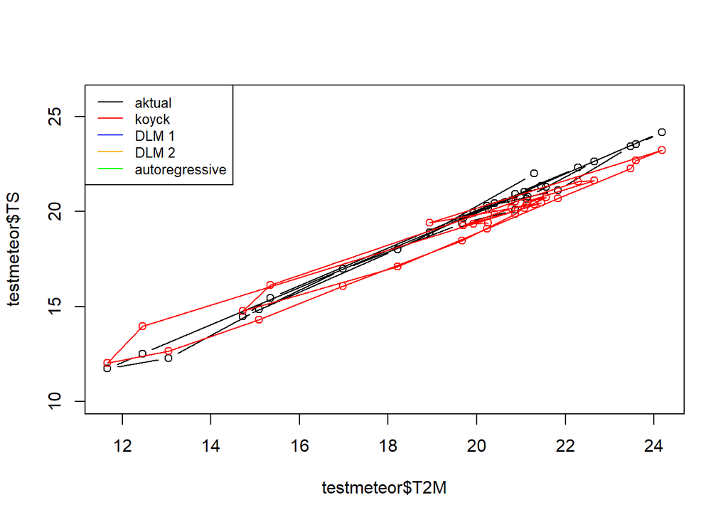

```r
plot(testmeteor$T2M, testmeteor$TS, type="b", col="black", ylim=c(10,26))
points(testmeteor$T2M, forekoyck$forecasts,col="red")
lines(testmeteor$T2M, forekoyck$forecasts,col="red")
legend("topleft",c("aktual", "koyck","DLM 1","DLM 2", "autoregressive"), lty=1, col=c("black","red","blue","orange","green"), cex=0.8)
```

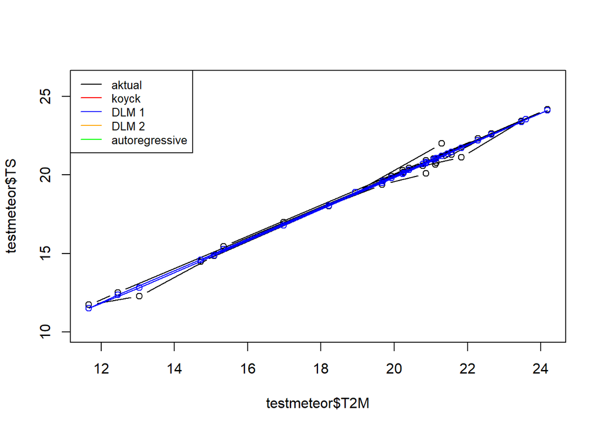

```r
plot(testmeteor$T2M, testmeteor$TS, type="b", col="black", ylim=c(10,26))
points(testmeteor$T2M, foredlm$forecasts,col="blue")
lines(testmeteor$T2M, foredlm$forecasts,col="blue")
legend("topleft",c("aktual", "koyck","DLM 1","DLM 2", "autoregressive"), lty=1, col=c("black","red","blue","orange","green"), cex=0.8)
```

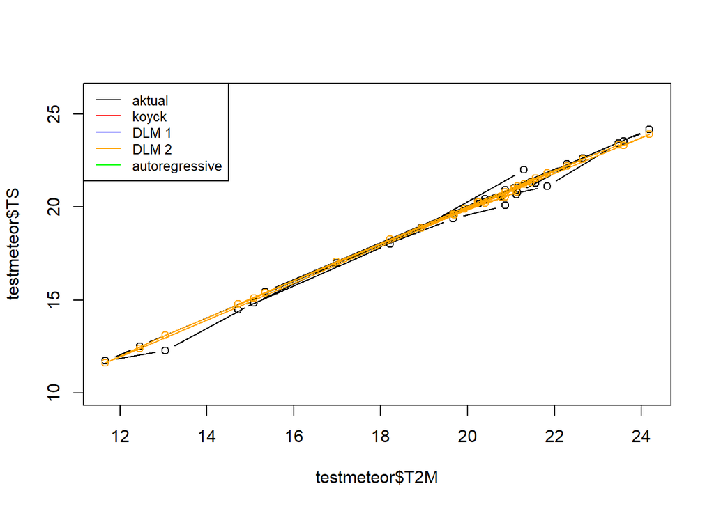

```r
plot(testmeteor$T2M, testmeteor$TS, type="b", col="black", ylim=c(10,26))
points(testmeteor$T2M, foredlm2$forecasts,col="orange")
lines(testmeteor$T2M, foredlm2$forecasts,col="orange")
legend("topleft",c("aktual", "koyck","DLM 1","DLM 2", "autoregressive"), lty=1, col=c("black","red","blue","orange","green"), cex=0.8)
```

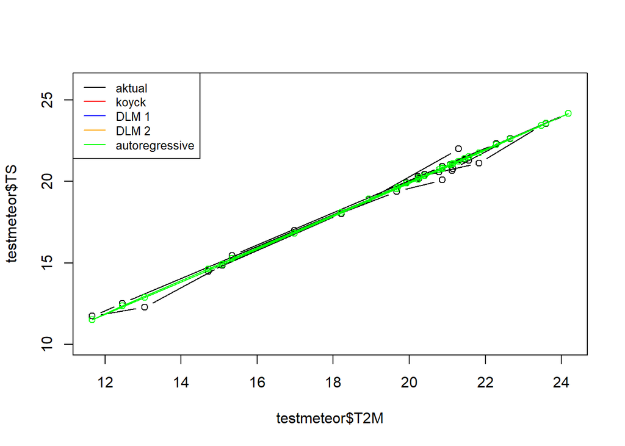

```r
plot(testmeteor$T2M, testmeteor$TS, type="b", col="black", ylim=c(10,26))
points(testmeteor$T2M, foreardl$forecasts,col="green")
lines(testmeteor$T2M, foreardl$forecasts,col="green")
legend("topleft",c("aktual", "koyck","DLM 1","DLM 2", "autoregressive"), lty=1, col=c("black","red","blue","orange","green"), cex=0.8)
```

Berdasarkan plot tersebut, terlihat bahwa plot yang paling mendekati data aktualnya adalah semua model kecuali Model koyck, sehingga dapat disimpulkan model terbaik dalam hal ini adalah DLM1, DLM2, dan autoregressive.